# Dependent Metric and Independent Categorical Variable Part 2

In this document, we want to answer the following research question: The more financial capital a student has available, the higher is a student’s aspiration for career success.

To answer this question, we need to load the data.

```r
library(psych)
data <- read.csv('survey_696322_R_data_file.csv')
data <- data[,c(3,5)]
indx <- sapply(data, is.factor)
data[indx] <- lapply(data[indx], as.numeric)
pca.result <- principal(data, nfactors = 1, scores = TRUE)
erfolg.scores <- pca.result$scores[,'PC1']
source('survey_696322_R_syntax_file.R')
data['erfolg'] <- erfolg.scores
```

Let’s look at the `Kapital` variable indicating the available monthly financial capital.

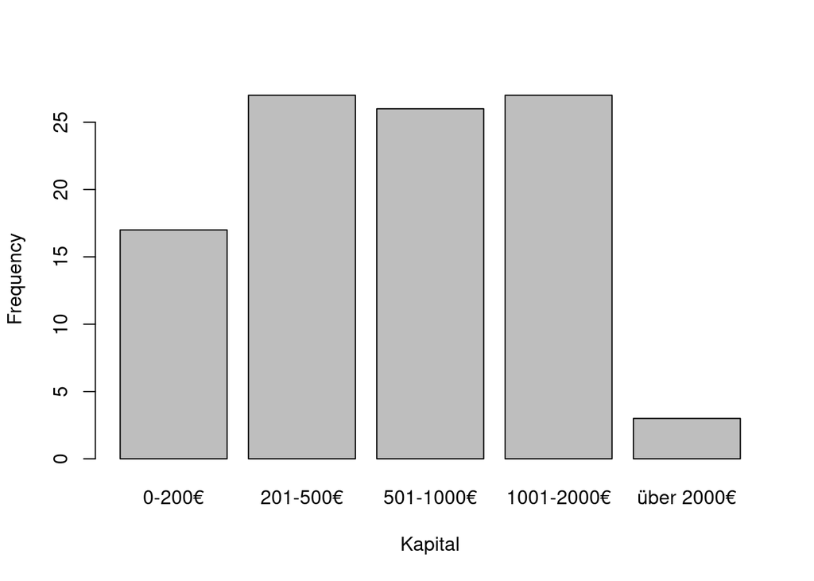

```r
plot(data$Q008, xlab = "Kapital", ylab = "Frequency")
```

We see that only three observations fall into the `über 2000€` category. We therefore decided to combine this level with the `1001-2000€` level. The newly created level is simply called `über 1000`.

```r
levels(data$Q008)[5] <- levels(data$Q008)[4]
levels(data$Q008)[4] <- "über 1000€"
```

Now let’s look at the summary statistics for the specific categories.

```r
describeBy(data$erfolg, group = data$Q008)
```

```
##
##  Descriptive statistics by group
## group: 0-200€
##    vars  n mean   sd median trimmed  mad   min  max range skew kurtosis
## X1    1 17 0.07 0.88    0.6    0.07 1.02 -1.14 1.28  2.42 -0.2    -1.63
##      se
## X1 0.21
## --------------------------------------------------------
## group: 201-500€
##    vars  n mean   sd median trimmed  mad   min  max range  skew kurtosis
## X1    1 27 0.02 1.08   0.07    0.04 1.02 -2.19 1.97  4.16 -0.27    -0.96
##      se
## X1 0.21
## --------------------------------------------------------
## group: 501-1000€
##    vars  n  mean   sd median trimmed mad   min  max range skew kurtosis
## X1    1 26 -0.26 0.84  -0.27   -0.29 0.9 -1.67 1.45  3.11 0.39    -0.67
##      se
## X1 0.16
## --------------------------------------------------------
## group: über 1000€
##    vars  n mean   sd median trimmed  mad   min  max range skew kurtosis
## X1    1 30 0.17 1.11  -0.09    0.17 1.26 -2.19 1.97  4.16 0.07    -0.86
##     se
## X1 0.2
```

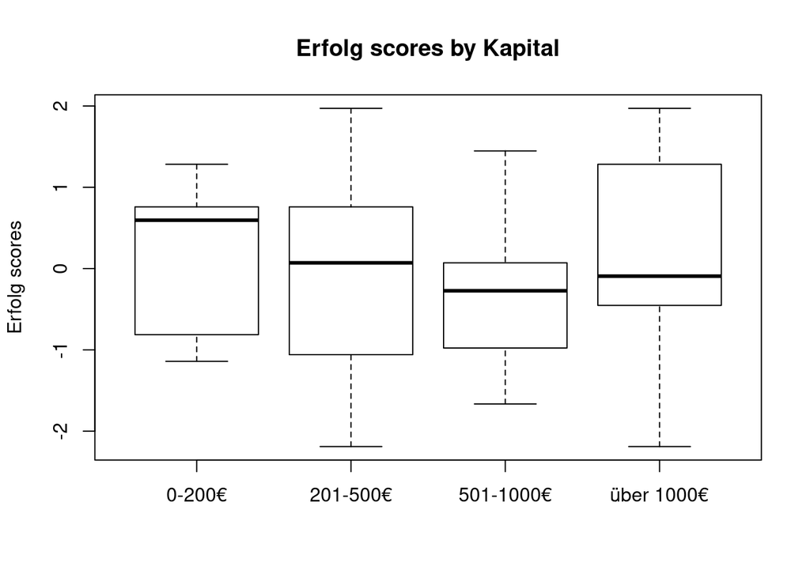

```r
boxplot(erfolg ~ Q008, data, ylab = "Erfolg scores", main = "Erfolg scores by Kapital")
```

We see in the above boxplot that the difference between the medians is rather minute. Additionally, we can see that the `Erfolg` scores are not normally distributed in the `0-200€`, `501-1000€` and `über 1000` categories.

Let’s see if a statistical test comes to the same conclusion. Due to the above insights, we know that we need a robust test. We decide to use the Kruskal-Wallis test using a significance level $\alpha=0.05$ with the following hypotheses:

- $H_0$: $\mu^{Erfolg}_{0-200€} = \mu^{Erfolg}_{201-500€} = \mu^{Erfolg}_{501-1000€} = \mu^{Erfolg}_{über 1000€}$
- $H_A$: At least one $\mu$ is different

```r
kruskal.test(erfolg ~ Q008, data)
```

```
##
##  Kruskal-Wallis rank sum test
##
## data:  erfolg by Q008
## Kruskal-Wallis chi-squared = 3.0127, df = 3, p-value = 0.3897
```

The Kruskall-Wallis test yields a p-value of roughly 0.4, which is higher than our $\alpha$. Therefore, we cannot reject $H_0$. We have no significant evidence of a difference in the means of the `Kapital` groups.